# Topic Modeling with BERTopic in R using reticulate and local LLMs

Author

Teodor Petrič

Published

May 10, 2025

The package `bertopicr` is based on the Python package `BERTopic` by Maarten Grootendorst (https://github.com/MaartenGr/BERTopic), which is described in his paper:

> **BERTopic: Neural topic modeling with a class-based TF-IDF procedure**  
> Maarten Grootendorst, 2022.  
> Available at: [arXiv:2203.05794](https://arxiv.org/abs/2203.05794)

The package `bertopicr` introduces functions to display topic model results of `BERTopic` models in `R`. The `R` package and the tutorial were created by using the programming advice of `OpenAI`’s language model `GPT4o`.

## 1 Env & Packages

*Load* the `R` packages below and *initialize* a `Python` environment with the `reticulate` package.

By default, `reticulate` uses an isolated `Python` *virtual environment* named `r-reticulate` (cf. https://rstudio.github.io/reticulate/).

The `use_python()` function below enables you to specify an alternate `Python` (cf. https://rstudio.github.io/reticulate/).

```r
library(dplyr)
library(tidyr)
library(purrr)
library(utils)
library(tibble)
library(readr)
library(tictoc)
library(htmltools)
library(arrow)
# interface with Python
library(reticulate)
# ~ Home, in cmd terminal insert: echo %USERPROFILE%
userprofile <- Sys.getenv("USERPROFILE")
use_python(file.path(userprofile, "anaconda3/envs/bertopic"), required = TRUE)
# use_python("path/to/your/python/env/bertopic", required = TRUE)
reticulate::py_config()
```

```
python:         C:/Users/teodo/anaconda3/envs/bertopic/python.exe
libpython:      C:/Users/teodo/anaconda3/envs/bertopic/python311.dll
pythonhome:     C:/Users/teodo/anaconda3/envs/bertopic
version:        3.11.12 | packaged by conda-forge | (main, Apr 10 2025, 22:09:00) [MSC v.1943 64 bit (AMD64)]
Architecture:   64bit
numpy:          C:/Users/teodo/anaconda3/envs/bertopic/Lib/site-packages/numpy
numpy_version:  1.26.4

NOTE: Python version was forced by use_python() function
```

```r
reticulate::py_available()
```

```
[1] TRUE
```

```r
library(bertopicr)
```

## 2 Text preparation

You need the `arrow` package to open the `parquet` file below.

The German texts are in the *text_clean* column. They were segmented into smaller chunks (each about 100 tokens long) to optimize topic extraction with `Bertopic`. Special characters were removed with a cleaning function. The text chunks are all in lower case.

```r
# Find the path
# parquet_path <- system.file("data", "spiegel_sample.parquet", package = "bertopicr")
# stopwords_path <- system.file("data", "all_stopwords.txt", package = "bertopicr")
parquet_path <- file.path("inst/extdata", "spiegel_sample.parquet")

# Read the parquet file using the correct path
library(arrow)
dataset <- arrow::read_parquet(parquet_path)

names(dataset)
```

```
 [1] "seq_id"      "doc_id"      "sentence_id" "genre"       "text_type"
 [6] "author"      "title"       "Text"        "text_clean"  "date"
```

```r
dim(dataset)
```

```
[1] 3000   10
```

The collected `stopword` list includes German and English tokens and will be inserted into `Python`’s `CountVectorizer` before `c-TF-IDF` calculation. The language model will be fed with the text chunks in the *text_clean* column before `stopword` removal.

```r
stopwords_path <- file.path("inst/extdata", "all_stopwords.txt")
all_stopwords <- read_lines(stopwords_path)
```

Below are the *texts_cleaned* and *timesteps* lists, which we need during the model preparation, topic extraction and visualization.

```r
texts_cleaned = dataset$text_clean
titles = dataset$doc_id
timestamps <- as.list(dataset$date)
# timestamps <- as.integer(dataset$year)

texts_cleaned[[1]]
```

```
[1] "leserinnen und leser der lokaljournalismus leert sich schleichend aber unerbittlich öffentliche hilfe sollte hier ansetzen noch wichtiger hier sollten die mittel auch ankommen und das stellt die demokratische medienrettung vor ein dilemma aus guten gründen wollen unabhängige verlage keine staat…
```

## 3 Model Preparation

For model preparation, we are going to use `reticulate` to interface with `Python` modules. The `R` code is essentially a conversion of `Python` code.

The Topic model preparation will also include *local* language models (via `ollama` or `lm-studio`) leveraging the `OpenAI` endpoint.

Before running the program chunk below, make sure to *install* all the necessary `Python` packages in a `virtual` environment or a `conda` environment (see short instructions in the README file or other tutorials online): `bertopic, numpy, scikit-learn, sentence-transformers, umap-learn, hdbscan, spacy, openai` and `datetime`. Download and install `ollama` or `lm-studio` on your computer to serve the *local* language model.

In `RStudio`, you can accomplish the installation of `Python` packages with `reticulate` commands: e.g., `reticulate::py_install ("bertopic", envname = "CHOOSE THE PATH YOUR PYTHON ENVIRONMENT")`.

If you are familiar working with a (windows or conda) `terminal`, you can activate the appropriate `python` or `conda` environment and install the necessary packages: e.g., `pip install bertopic`).

### 3.1 Python packages

First, we `import` the necessary `Python` packages: `numpy, umap, hdbscan, scikit-learn, sentence_transformers, and bertopic`.

```r
# Import necessary Python modules
np <- import("numpy")
umap <- import("umap")
UMAP <- umap$UMAP
hdbscan <- import("hdbscan")
HDBSCAN <- hdbscan$HDBSCAN
sklearn <- import("sklearn")
CountVectorizer <- sklearn$feature_extraction$text$CountVectorizer
bertopic <- import("bertopic")
plotly <- import("plotly")
datetime <- import("datetime")
```

### 3.2 Embeddings

`SentenceTransformer` creates the necessary *embeddings* (vector representations of text tokens) for topic modeling with `bertopic`. The first time `SentenceTransformer` is used with a specific model, the model has to been downloaded from the `huggingface` website (https://huggingface.co/), where many freely usable language models are hosted (https://huggingface.co/models).

```r
# Embed the sentences
py <- import_builtins()
sentence_transformers <- import("sentence_transformers")
SentenceTransformer <- sentence_transformers$SentenceTransformer
embedding_model = SentenceTransformer("BAAI/bge-m3") # for multiple languages
embeddings = embedding_model$encode(texts_cleaned, show_progress_bar=TRUE)
```

### 3.3 Dimension reduction

In the next two steps, the `umap` module reduces the number of dimensions of embeddings, and the `hdbscan` module extracts clusters that can evaluated by the topic pipeline.

```r
# Initialize UMAP and HDBSCAN models
umap_model <- UMAP(n_neighbors=15L, n_components=5L, min_dist=0.0, metric='cosine', random_state=42L)
```

Other dimension reduction methods (like `PCA` or `tSNE`) can be used instead.

### 3.4 Clustering

The `hdbscan` module extracts clusters that can evaluated by the topic pipeline.

```r
hdbscan_model <- HDBSCAN(min_cluster_size=15L, min_samples = 10L, metric='euclidean', cluster_selection_method='eom', gen_min_span_tree=TRUE, prediction_data=TRUE, core_dist_n_jobs = 1)
```

Other `clustering` methods (like `kmeans`) can be used instead.

### 3.5 c-TF-IDF

The `Countvectorizer` calculates the `c-TF-IDF` frequencies and enables the `representation model` defined below to extract suitable keywords as descriptors of the extracted topics.

`Stopwords` are removed *after* creating `embeddings`, but *before* `keyword` extraction. Stopword removal is accomplished with a `CountVectorizer` option.

```r
# Initialize CountVectorizer
vectorizer_model <- CountVectorizer(min_df=2L, ngram_range=tuple(1L, 3L),
                                    max_features = 10000L, max_df = 50L,
                                    stop_words = all_stopwords)
sentence_vectors <- vectorizer_model$fit_transform(texts_cleaned)
sentence_vectors_dense <- np$array(sentence_vectors)
sentence_vectors_dense <- py_to_r(sentence_vectors_dense)
```

### 3.6 Representation models

In the example below, *multiple representation models* are used for keyword extraction from the identified topics and topic description: `keyBERT` (part of `bertopic`), a language model (served locally by `ollama` or online by `Groq`, both via the `OpenAI` endpoint), a Maximal Marginal Relevance model (`MMR`) and a `spacy` `POS` representation model. By default, only one Representation model is created by `bertopic`.

```r
# Initialize representation models
keybert_model <- bertopic$representation$KeyBERTInspired()
openai <- import("openai")
OpenAI <- openai$OpenAI
ollama <- import("ollama")

# Point to the local server (ollama or lm-studio)
client <- OpenAI(base_url = 'http://localhost:11434/v1', api_key='ollama')
# client <- OpenAI(base_url = 'http://localhost:1234/v1', api_key='lm-studio')

prompt <- "
I have a topic that contains the following documents:
[DOCUMENTS]
The topic is described by the following keywords: [KEYWORDS]

Based on the information above, extract a short but highly descriptive topic label of at most 5 words. Make sure it is in the following format:
topic: <topic label>
"

# download an appropriate local LLM for your computer with ollama/lm-studio
# e.g., insert in your terminal 'ollama pull llama3.1'
openai_model <- bertopic$representation$OpenAI(client,
                                               # model = "qwen3",
                                               # model = "gemma3:4b",
                                               model = "qwen2.5:14b-instruct",
                                               # model = "llama3.1:8b-instruct-fp16",
                                               exponential_backoff = TRUE,
                                               chat = TRUE,
                                               prompt = prompt)

# downlaod a spacy language model from spacy.io suitable for your computer
# before usage insert in your terminal 'python -m spacy download de_core_news_md'
pos_model <- bertopic$representation$PartOfSpeech("de_core_news_md")
# diversity set relatively high to reduce repetition of keyword word forms
mmr_model <- bertopic$representation$MaximalMarginalRelevance(diversity = 0.5)

# Combine all representation models
representation_model <- list(
  "KeyBERT" = keybert_model,
  "OpenAI" = openai_model,
  "MMR" = mmr_model,
  "POS" = pos_model
)
```

The *prompt* describes the task the language model has to accomplish, mentions the documents to work with and the topic labels that it should derive from the text contents and keywords.

### 3.7 Zeroshot keywords

`Bertopic` enables us to define a `zeroshot` list of keywords that can be used to drive the topic model towards desired topic outcomes. In the code below, the zeroshot keyword search is disabled, but can be activated if needed.

```r
# We can define a number of topics that we know are in the documents
zeroshot_topic_list  <- list("german national identity", "minority issues in germany")
```

### 3.8 Topic Model

```r
# Initialize BERTopic model with pipeline models and hyperparameters
BERTopic <- bertopic$BERTopic
topic_model <- BERTopic(
  embedding_model = embedding_model,
  umap_model = umap_model,
  hdbscan_model = hdbscan_model,
  vectorizer_model = vectorizer_model,
  # zeroshot_topic_list = zeroshot_topic_list,
  # zeroshot_min_similarity = 0.85,
  representation_model = representation_model,
  calculate_probabilities = TRUE,
  top_n_words = 10L,
  verbose = TRUE
)
```

### 3.9 Model Training

After all these preparational steps, the topic model is trained with: `topic_model$fit_transform(texts, embeddings)`.

```r
tictoc::tic()

# Fit the model and transform the texts
fit_transform <- topic_model$fit_transform(texts_cleaned, embeddings)
topics <- fit_transform[[1]]
# probs <- fit_transform[[2]]

# Now transform the texts to get the updated probabilities
transform_result <- topic_model$transform(texts_cleaned)
probs <- transform_result[[2]]  # Extract the updated probabilities

tictoc::toc()
```

```
47.67 sec elapsed
```

We obtain the *topic labels* with `topics <- fit_transform[[1]]` and the *topic probabilities* with `probs <- fit_transform[[2]]`.

### 3.10 Topic Dynamics

Since our dataset contains time-related metadata, we can use the `timestamps` for `dynamic topic modeling`, i.e., for discovering topic development or topic sequences through time. If your data doesn’t contain any time-related column, the timestamps and topics_over_time calculations have to be disabled.

```r
# Converting R Date to Python datetime
datetime <- import("datetime")

timestamps <- as.list(dataset$date)
# timestamps <- as.integer(dataset$year)

# Convert each R date object to an ISO 8601 string
timestamps <- lapply(timestamps, function(x) {
  format(x, "%Y-%m-%dT%H:%M:%S")  # ISO 8601 format
})

# Dynamic topic model
topics_over_time  <- topic_model$topics_over_time(texts_cleaned, timestamps, nr_bins=20L, global_tuning=TRUE, evolution_tuning=TRUE)
```

### 3.11 Store Results

The *topic labels* and *probabilities* are stored in a dataframe named *results*, together with other variables and metadata.

```r
# Combine results with additional columns
results <- dataset |>
  mutate(Topic = topics,
         Probability = apply(probs, 1, max))  # Assuming the highest probability for each sentence

results <- results |>
  mutate(row_id = row_number()) |>
  select(row_id, everything())

head(results,10) |> rmarkdown::paged_table()
```

| row_id | seq_id | doc_id | sentence_id | genre | text_type | author | title | Text | text_clean | date | Topic | Probability |
| --- | --- | --- | --- | --- | --- | --- | --- | --- | --- | --- | --- | --- |
| 1 | 21814 | 2162 | 4 | Gastbeitrag | Ein Gastbeitrag von Sebastian Turner | NA | Ein Gutschein für die Tageszeitung | Leserinnen und Leser. Der Lokaljournalismus leert sich schleichend, aber unerbittlich. Öffentliche Hilfe sollte hier ansetzen. Noch wichtiger: Hier sollten die Mittel auch ankommen. Und das stellt die… | leserinnen und leser der lokaljournalismus leert sich schleichend aber unerbittlich öffentliche hilfe sollte hier ansetzen noch wichtiger hier sollten die mittel auch ankommen und das stellt die demok… | 2020-04-29 | -1 | 0.05010504 |
| 2 | 12627 | 1255 | 4 | Kolumne | Eine Kolumne von Samira El Ouassil | Samira El Ouassil | Vom Impfen und Schimpfen | kann vor allem dann auftreten, wenn es sich um eine Verletzung des Prinzips ›Wer zuerst kommt, mahlt zuerst‹ handelt oder um das, was die Leute für Fairness halten. « Fairness ist hier das Schlüsselwo… | kann vor allem dann auftreten wenn es sich um eine verletzung des prinzips wer zuerst kommt mahlt zuerst handelt oder um das was die leute für fairness halten fairness ist hier das schlüsselwort in ei… | 2021-04-08 | -1 | 0.01945922 |
| 3 | 8215 | 780 | 12 | Kolumne | Eine Kolumne von Thomas Fricke | Thomas Fricke | Der Unsinn von der teuren Klimarettung | Investitionen finanziell zu unterstützen. Klingt enorm, ist nur bei näherem Hinsehen auch kein Grund, in tiefe Kostendepression zu fallen. Die Summe verteilt sich auf ein ganzes Jahrzehnt, und wir sin… | investitionen finanziell zu unterstützen klingt enorm ist nur bei näherem hinsehen auch kein grund in tiefe kostendepression zu fallen die summe verteilt sich auf ein ganzes jahrzehnt und wir sind wir… | 2021-11-12 | 1 | 0.91919209 |
| 4 | 55125 | 6097 | 2 | OTHER | Von Wolfgang Münchau | Wolfgang Münchau | Was 2015 mit 1914 gemeinsam hat | Ausdruck benutze, denn Politik, und gerade Wirtschaftspolitik, besteht aus der Wahl zwischen Alternativen. Doch in diesem Fall ist der Ausdruck angemessen. Der Schuldenschnitt, ob verhandelt oder eins… | ausdruck benutze denn politik und gerade wirtschaftspolitik besteht aus der wahl zwischen alternativen doch in diesem fall ist der ausdruck angemessen der schuldenschnitt ob verhandelt oder einseitig … | 2015-07-06 | 15 | 1.00000000 |
| 5 | 55242 | 6115 | 6 | OTHER | Von Sascha Lobo | Sascha Lobo | Meinungsbildung à la Internet | sozialen Medien eine Art Kuratorennetzwerk geschaffen. Ich vertraue bestimmten Personen in meinem digitalen Umfeld zu bestimmten Themen. Zum Thema Griechenland sind das ein Dutzend Personen, die über … | sozialen medien eine art kuratorennetzwerk geschaffen ich vertraue bestimmten personen in meinem digitalen umfeld zu bestimmten themen zum thema griechenland sind das ein dutzend personen die über fac… | 2015-07-01 | 3 | 0.23891814 |
| 6 | 27620 | 2776 | 5 | OTHER | Von Marcel Fratzscher | NA | Bloß keine Neiddebatte! | der ungewöhnlich große Niedriglohnbereich in Deutschland, die viele Menschen daran hindern, Vorsorge zu betreiben und Erspartes aufbauen zu können. Und die dritte Frage ist: Wie können private Vermöge… | der ungewöhnlich große niedriglohnbereich in deutschland die viele menschen daran hindern vorsorge zu betreiben und erspartes aufbauen zu können und die dritte frage ist wie können private vermögen be… | 2019-08-26 | 8 | 0.63124724 |
| 7 | 38790 | 4048 | 7 | OTHER | Von Christian Stöcker | Christian Stöcker | Bitte nicht mehr "Fake News" sagen | Lüge" erklärt, die nur mit der "geballten Faust der Wahrheit" bekämpft werden könne. Die Protagonistin des Videos, die NRA-Lobbyistin Dana Loesch, war gerade in Florida: Sie nahm an einer öffentlichen… | lüge erklärt die nur mit der geballten faust der wahrheit bekämpft werden könne die protagonistin des videos die nra lobbyistin dana loesch war gerade in florida sie nahm an einer öffentlichen veranst… | 2018-02-25 | 5 | 0.73995136 |
| 8 | 21820 | 2163 | 2 | Kommentar | Ein Kommentar von Michael Kröger | Michael Kröger | Kauf ein Auto, kassiere die Prämie, hilf damit allen! | Herausforderung zu den größeren im Zusammenhang mit der Coronakrise zählen würde, war von vorneherein klar - doch es wird wohl noch schwieriger als befürchtet. Wie weit die Positionen auseinander lieg… | herausforderung zu den größeren im zusammenhang mit der coronakrise zählen würde war von vorneherein klar doch es wird wohl noch schwieriger als befürchtet wie weit die positionen auseinander liegen z… | 2020-04-29 | -1 | 0.12862573 |
| 9 | 2024 | 196 | 2 | Kolumne | Eine Kolumne von Christian Stöcker | Christian Stöcker | Petro-Männchen blenden die Wirklichkeit aus | die globale Spitzenbedrohung.« Tatsächlich landete der Klimawandel bei der Frage, ob man etwas als »große Bedrohung, kleinere Bedrohung oder keine Bedrohung« für das eigene Land einschätze, in den mei… | die globale spitzenbedrohung tatsächlich landete der klimawandel bei der frage ob man etwas als große bedrohung kleinere bedrohung oder keine bedrohung für das eigene land einschätze in den meisten de… | 2022-09-04 | 1 | 0.49582244 |
| 10 | 16519 | 1639 | 11 | Kolumne | Eine Kolumne von Samira El Ouassil | Samira El Ouassil | Die Super-Migranten | unterschätzenden Punkt: eine Art "Kamala-Harris-Effekt", einen empirisch messbaren Zusammenhang zwischen Repräsentation, Identifikation und der integrativen Kraft von Vorbildern, die einem selbst ähnl… | unterschätzenden punkt eine art kamala harris effekt einen empirisch messbaren zusammenhang zwischen repräsentation identifikation und der integrativen kraft von vorbildern die einem selbst ähnlich si… | 2020-11-12 | 23 | 0.90873539 |

```r
results |>
  saveRDS("data/spiegel_topic_results_df.rds")
results |>
  write_parquet("data/spiegel_topic_results_df.parquet")
results |>
  write_csv("data/spiegel_topic_results_df.csv")
results |>
  writexl::write_xlsx("data/spiegel_topic_results_df.xlsx")
```

## 4 Results

The `R` package `bertopicr` will be used in this section to display the topic modeling results in the form of lists, data frames and visualizations. The names of the functions are nearly the same as in the `Python` package `BERTopic`.

### 4.1 Document information

The `get_document_info_df()` creates a dataframe that contains the documents and associated topics, characteristics keywords, probability scores, representative documents of a each topic and representation model results (e.g., keywords extracted by `KeyBERT`, `MMR`, `spacy`, and `LLM` descriptions of the topics).

```r
library(bertopicr)
document_info_df <- get_document_info_df(model = topic_model,
                                         texts = texts_cleaned,
                                         drop_expanded_columns = TRUE)
document_info_df |> head() |> rmarkdown::paged_table()
```

| Document | Topic | Name | Top_n_words | Probability | Representative_document | Representation | KeyBERT | OpenAI | MMR | POS | Representative_Docs |
| --- | --- | --- | --- | --- | --- | --- | --- | --- | --- | --- | --- |
| leserinnen und leser der lokaljournalismus leert sich schleichend aber unerbittlich öffentliche hilfe sollte hier ansetzen noch wichtiger hier sollten die mittel auch ankommen und das stellt die demok… | -1 | -1_menschen_deutschland_deutschen_leben | menschen - deutschland - deutschen - leben - welt - leute - gut - zeit - gerade - deutsche | 0.80635481 | FALSE | menschen, deutschland, deutschen, leben, welt, leute, gut, zeit, gerade, deutsche | deutschland, denken, deutschen, richtig, überhaupt, menschen, sprechen, problem, gehört, demokratie | German Society and Politics Critique | menschen, deutschland, frage, euro, lässt, beispiel, angst, politiker, afd, große | menschen, deutschen, leben, welt, leute, zeit, deutsche, land, jahren, frage | stellen sie sich vor sie leben in der schweiz und terroristen bringen menschen um acht deutsche und einen österreicher den sie für einen deutschen halten und begehen bombenanschläge auf deutsche gesch… |
| kann vor allem dann auftreten wenn es sich um eine verletzung des prinzips wer zuerst kommt mahlt zuerst handelt oder um das was die leute für fairness halten fairness ist hier das schlüsselwort in ei… | -1 | -1_menschen_deutschland_deutschen_leben | menschen - deutschland - deutschen - leben - welt - leute - gut - zeit - gerade - deutsche | 0.67701688 | FALSE | menschen, deutschland, deutschen, leben, welt, leute, gut, zeit, gerade, deutsche | deutschland, denken, deutschen, richtig, überhaupt, menschen, sprechen, problem, gehört, demokratie | German Society and Politics Critique | menschen, deutschland, frage, euro, lässt, beispiel, angst, politiker, afd, große | menschen, deutschen, leben, welt, leute, zeit, deutsche, land, jahren, frage | stellen sie sich vor sie leben in der schweiz und terroristen bringen menschen um acht deutsche und einen österreicher den sie für einen deutschen halten und begehen bombenanschläge auf deutsche gesch… |
| investitionen finanziell zu unterstützen klingt enorm ist nur bei näherem hinsehen auch kein grund in tiefe kostendepression zu fallen die summe verteilt sich auf ein ganzes jahrzehnt und wir sind wir… | 1 | 1_co_klima_vw_klimawandel | co - klima - vw - klimawandel - autos - wasser - grad - kosten - auto - prozent | 0.13394698 | FALSE | co, klima, vw, klimawandel, autos, wasser, grad, kosten, auto, prozent | fürs klima, energiewende, klimaschutz, emissionen, klimapolitik, klimakrise, klimawandel, elektroautos, erneuerbare, autos | Climate Costs and Subsidies | wasser, kosten, milliarden, klimakrise, unternehmen, cent, strom, elektroautos, endlich, greta | co, klima, klimawandel, autos, wasser, grad, kosten, auto, prozent, milliarden | atemberaubende milliarden us dollar im jahr richtig dollar ein iwf update vom september ergab milliarden us dollar entsprechend prozent der weltweiten wirtschaftsleistung die subventionen steigen demn… |
| ausdruck benutze denn politik und gerade wirtschaftspolitik besteht aus der wahl zwischen alternativen doch in diesem fall ist der ausdruck angemessen der schuldenschnitt ob verhandelt oder einseitig … | 15 | 15_griechenland_eu_merkel_euro | griechenland - eu - merkel - euro - schulden - griechen - europäischen - europa - angela - währungsunion | 1.00000000 | FALSE | griechenland, eu, merkel, euro, schulden, griechen, europäischen, europa, angela, währungsunion | euro krise, griechenland euro, schulden, merkel, griechenland, schuldenkrise, europa, griechen, eu, euro | Greek Debt Crisis and EU Relations | merkel, schulden, europa, angela, währungsunion, regierungen, syriza, griechenland euro, finanzminister, gläubiger | euro, schulden, griechen, europäischen, währungsunion, brüssel, krise, regierungen, syriza, gemeinsame | monate sind eine lange zeit gut milliarden euro hilfskredite eine menge geld und drei athener regierungen ziemlich viel politik trotzdem steht griechenland unmittelbar vor dem staatsbankrott eine athe… |
| sozialen medien eine art kuratorennetzwerk geschaffen ich vertraue bestimmten personen in meinem digitalen umfeld zu bestimmten themen zum thema griechenland sind das ein dutzend personen die über fac… | 3 | 3_facebook_medien_google_sozialen | facebook - medien - google - sozialen - vorratsdatenspeicherung - internet - snowden - sozialen medien - digitalen - öffentlichkeit | 0.06134811 | TRUE | facebook, medien, google, sozialen, vorratsdatenspeicherung, internet, snowden, sozialen medien, digitalen, öffentlichkeit | sozialen medien, soziale medien, social, twitter, soziale, internet, öffentlichkeit, sozialen, facebook, debatten | Social Media and Digital Oversight | google, vorratsdatenspeicherung, snowden, sozialen medien, algorithmen, jahrhundert, geheimdienste, aufmerksamkeit, liberalismus, funktioniert | facebook, medien, sozialen, vorratsdatenspeicherung, internet, snowden, sozialen medien, digitalen, öffentlichkeit, intelligenz | ende verwendeten prozent der internetnutzer dort soziale medien in deutschland prozent auch deshalb markiert der türkische bürgeraufstand eine neue qualität die funktionen der sozialen medien spreizen… |
| der ungewöhnlich große niedriglohnbereich in deutschland die viele menschen daran hindern vorsorge zu betreiben und erspartes aufbauen zu können und die dritte frage ist wie können private vermögen be… | 8 | 8_deutschland_prozent_arbeitslosigkeit_schulden | deutschland - prozent - arbeitslosigkeit - schulden - rezession - gut - steuern - wirtschaft - euro - stark | 0.17627855 | FALSE | deutschland, prozent, arbeitslosigkeit, schulden, rezession, gut, steuern, wirtschaft, euro, stark | deutschland, hierzulande, steuern abgaben, schulden, schlecht, prozent wirtschaftsleistung, produktivität, steigende, deutschen, wirtschaft | German Economy and Financial Crises | deutschland, schulden, rezession, gut, euro, wirtschaftsleistung, ungleichheit, deutlich, milliarden, produktivität | prozent, arbeitslosigkeit, schulden, rezession, steuern, wirtschaft, euro, deutsche, einkommen, wirtschaftsleistung | vergleich in deutschland die arbeitseinkommen recht stark und die vermögenseinkommen ungewöhnlich gering besteuert was letztlich nicht nur die wirtschaftliche und gesellschaftliche polarisierung verst… |

### 4.2 Representative docs

First, create a data frame similar to *df_docs* below, which contains the columns Topic, Document and probs. Then use the `get_most_representative_docs()` function to extract representative documents of a chosen topic.

```r
# Create a data frame similar to df_docs
df_docs <- tibble(Topic = results$Topic,
                  Document = results$text_clean,
                  probs = results$Probability)
rep_docs <- get_most_representative_docs(df = df_docs,
                                         topic_nr = 3,
                                         n_docs = 5)
unique(rep_docs)
```

```
[1] "fast alle ein mit sensoren vollgestopftes gerät mit sich herumtragen und ein immer größerer teil des lebens online stattfindet kann man sehr viel messen plötzlich existieren datenströme die auskunft geben über das fahrverhalten weil die bewegungsdaten des smartphones analysiert werden können da…
[2] "die meisten menschen meinen dass digitalisierung ist wenn man per app seine seele dem teufel verkaufen oder auf ein fußballspiel in japan wetten kann so ähnlich geht es auch mit der künstlichen intelligenz sie ist ungefähr so segensreich wie die in den fünfzigerjahren prognostizierten atomgetri…
[3] "sollten sehr vorsichtig sein mit der künstlichen intelligenz wenn ich raten sollte was die größte bedrohung unserer existenz darstellt wäre es künstliche intelligenz bumm es war nicht das erste mal dass sich musk kritisch gegenüber dieser technologieform geäußert hat aber auch nicht das letzte …
[4] "kontrolliert wird ein digitaler algorithmen staat hätte ganz andere möglichkeiten er könnte die fahrgeschwindigkeit eines jeden autos in echtzeit kontrollieren und theoretisch bußgelder direkt von den konten der verkehrssünder abbuchen in der privatwirtschaft haben sich solche lückenlosen überw…
[5] "sondern eine maschine erzeugt sie zeigen augenscheinlich in öl gemalte perserkatzen die entsetzt traurig oder wütend auf ihre smartphones starren offenbar weil sie mit ihren bitcoins so viel geld verloren haben es ist als mache eine künstliche intelligenz einen witz auf kosten der kryptowährung…
```

### 4.3 Topic information

The function `get_topic_info_df()` creates another useful data frame, which for each of the extracted topics shows the number of associated documents (or text chunks), topic id (Name), characeristic keywords according to the chosen representation models and three (concatenated) representative documents.

```r
topic_info_df <- get_topic_info_df(model = topic_model,
                                   drop_expanded_columns = TRUE)
head(topic_info_df) |> rmarkdown::paged_table()
```

| Topic | Count | Name | Representation | KeyBERT | OpenAI | MMR | POS | Representative_Docs |
| --- | --- | --- | --- | --- | --- | --- | --- | --- |
| -1 | 1303 | -1_menschen_deutschland_deutschen_leben | menschen, deutschland, deutschen, leben, welt, leute, gut, zeit, gerade, deutsche | deutschland, denken, deutschen, richtig, überhaupt, menschen, sprechen, problem, gehört, demokratie | German Society and Politics Critique | menschen, deutschland, frage, euro, lässt, beispiel, angst, politiker, afd, große | menschen, deutschen, leben, welt, leute, zeit, deutsche, land, jahren, frage | stellen sie sich vor sie leben in der schweiz und terroristen bringen menschen um acht deutsche und einen österreicher den sie für einen deutschen halten und begehen bombenanschläge auf deutsche gesch… |
| 0 | 163 | 0_merkel_spd_kanzlerin_partei | merkel, spd, kanzlerin, partei, cdu, grünen, union, csu, angela, koalition | merkel, großen koalition, große koalition, kanzlerin, koalition, kanzler, angela merkel, politischen, grünen, grüne | German Politics and Coalitions | merkel, partei, grünen, csu, afd, wähler, seehofer, habeck, bundestagswahl, scholz | kanzlerin, partei, grünen, union, koalition, söder, wähler, zeit, politik, wahl | die spd kann aufatmen spätestens löst sich das problem merkel von selbst dann tritt die kanzlerin nämlich zurück das behauptet jedenfalls bild zeitungs redakteur nikolaus blome in seinem neuen buch üb… |
| 1 | 125 | 1_co_klima_vw_klimawandel | co, klima, vw, klimawandel, autos, wasser, grad, kosten, auto, prozent | fürs klima, energiewende, klimaschutz, emissionen, klimapolitik, klimakrise, klimawandel, elektroautos, erneuerbare, autos | Climate Costs and Subsidies | wasser, kosten, milliarden, klimakrise, unternehmen, cent, strom, elektroautos, endlich, greta | co, klima, klimawandel, autos, wasser, grad, kosten, auto, prozent, milliarden | atemberaubende milliarden us dollar im jahr richtig dollar ein iwf update vom september ergab milliarden us dollar entsprechend prozent der weltweiten wirtschaftsleistung die subventionen steigen demn… |
| 2 | 125 | 2_putin_ukraine_russland_putins | putin, ukraine, russland, putins, russischen, russische, präsident, kreml, ukrainische, krieg | putin, putins, wladimir putin, ukrainische, russische, ukraine, ukrainischen, russland, russischen, kreml | Putin and Russia-Ukraine Relations | putin, kreml, ukrainische, gas, nord stream, februar, sanktionen, nato, präsidenten, krieges | putin, russland, putins, russischen, russische, präsident, kreml, ukrainische, krieg, gas | auch wahr machen wird trotzdem lautet faustregel zwei wenn putin sagt was er nicht will meint er das ernst kategorie drei es gibt viele direkte putin zitate die einen im nachhinein vor ein rätsel stel… |
| 3 | 125 | 3_facebook_medien_google_sozialen | facebook, medien, google, sozialen, vorratsdatenspeicherung, internet, snowden, sozialen medien, digitalen, öffentlichkeit | sozialen medien, soziale medien, social, twitter, soziale, internet, öffentlichkeit, sozialen, facebook, debatten | Social Media and Digital Oversight | google, vorratsdatenspeicherung, snowden, sozialen medien, algorithmen, jahrhundert, geheimdienste, aufmerksamkeit, liberalismus, funktioniert | facebook, medien, sozialen, vorratsdatenspeicherung, internet, snowden, sozialen medien, digitalen, öffentlichkeit, intelligenz | ende verwendeten prozent der internetnutzer dort soziale medien in deutschland prozent auch deshalb markiert der türkische bürgeraufstand eine neue qualität die funktionen der sozialen medien spreizen… |
| 4 | 120 | 4_corona_pandemie_virus_menschen | corona, pandemie, virus, menschen, impfen, schulen, gerade, gut, impfstoffe, maßnahmen | einschränkungen, corona, infizierten, hierzulande, maskenpflicht, schutzmaßnahmen, impfen, beobachten, menschen, corona pandemie | Corona Pandemic Measures and Impacts | impfen, schulen, maßnahmen, coronakrise, deutschland, tests, form, kitas, robert koch, instituts | corona, pandemie, virus, menschen, schulen, impfstoffe, maßnahmen, studie, drosten, coronakrise | bitte wickelt kilometer vor berlin das handy in alufolie ein ausschalten reicht nicht derartige maßnahmen werden jetzt wohl nicht nötig sein der berliner senat hat die geplante demonstration gegen die… |

### 4.4 Words in Topics

The `get_topics_df()` function concentrates on the words associated with a certain topic and their probability scores. The outliers (Topic = -1) usually are not included in the analysis. But BERTopic offers a function to reduce the number of outliers and to update the topic model.

```r
topics_df <- get_topics_df(model = topic_model)
head(topics_df, 30)
```

```
# A tibble: 30 × 3
   Word          Score Topic
   <chr>         <dbl> <dbl>
 1 menschen    0.0149     -1
 2 deutschland 0.0132     -1
 3 deutschen   0.0101     -1
 4 leben       0.00911    -1
 5 welt        0.00864    -1
 6 leute       0.00825    -1
 7 gut         0.00799    -1
 8 zeit        0.00799    -1
 9 gerade      0.00780    -1
10 deutsche    0.00735    -1
# ℹ 20 more rows
```

### 4.5 Topic Barchart

The `visualize_barchart()` creates an interactive barchart with the top five words of the most frequently occurring topics.

```r
visualize_barchart(model = topic_model,
                   filename = "topics_topwords_interactive_barchart", # default
                   open_file = FALSE) # TRUE enables output in browser
```

[figure not shown]

We might prefer to create an easy customizable barchart with the `ggplot2` package by using the dataframe extracted by the `get_topics_df()` function and run the `plotly` library in `R` with the `ggplotly()` function for an interactive barchart.

```r
library(ggplot2)

barchart <- topics_df |>
  group_by(Topic) |>
  filter(Topic >= 0 & Topic <= 8) |>
  slice_head(n=5) |>
  mutate(Topic = paste("Topic", as.character(Topic)),
         Word = reorder(Word, Score)) |>
  ggplot(aes(Score, Word, fill = Topic)) +
  geom_col() +
  facet_wrap(~ Topic, scales = "free") +
  theme(legend.position = "none")

library(plotly)
ggplotly(barchart)
```

[output not shown]

### 4.6 Find Topics

The `find_topics_df()` function is useful for semantic search. It can identify topics that are associated with a chosen query or multiple queries.

```r
find_topics_df(model = topic_model,
               queries = "migration", # user input
               top_n = 10, # default
               return_tibble = TRUE) # default
```

```
# A tibble: 10 × 3
   keyword   topics similarity
   <chr>      <int>      <dbl>
 1 migration     17      0.563
 2 migration     21      0.511
 3 migration     -1      0.508
 4 migration      0      0.484
 5 migration      2      0.482
 6 migration     11      0.481
 7 migration     14      0.477
 8 migration     12      0.477
 9 migration     24      0.473
10 migration     13      0.472
```

```r
find_topics_df(model = topic_model,
                               queries = c("migranten", "asylanten"),
                               top_n = 5)
```

```
# A tibble: 10 × 3
   keyword   topics similarity
   <chr>      <int>      <dbl>
 1 migranten     17      0.635
 2 migranten     -1      0.551
 3 migranten     12      0.549
 4 migranten     21      0.543
 5 migranten      2      0.528
 6 asylanten     17      0.561
 7 asylanten     24      0.526
 8 asylanten     12      0.503
 9 asylanten     21      0.500
10 asylanten     -1      0.498
```

### 4.7 Get Topics

The `get_topic_df()` function creates a dataframe and extracts the top words of a chosen topic.

```r
get_topic_df(model = topic_model,
                           topic_number = 0,
                           top_n = 5, # default is 10
                           return_tibble = TRUE) # default
```

```
# A tibble: 5 × 3
  Word       Score Topic
  <chr>      <dbl> <int>
1 merkel    0.0467     0
2 spd       0.0409     0
3 kanzlerin 0.0285     0
4 partei    0.0272     0
5 cdu       0.0265     0
```

### 4.8 Topic Distribution

The `visualize_distribution()` function produces an interactive barchart that displays the associated topics of a chosen document (or text chunk). The probability scores help to identify the most likely topic(s) of a document (or text chunk).

```r
# default filename: topic_dist_interactive.html
visualize_distribution(model = topic_model,
                       text_id = 1, # user input
                       probabilities = probs, # see model training
                       filename = "topic_dist_interactive", # default name
                       auto_open = FALSE) # TRUE enables output in browser
```

[figure not shown]

### 4.9 Intertopic Distance Map

The semantic relatedness of topics can be displayed with the `visualize_topics()` function.

```r
visualize_topics(model = topic_model,
                 filename = "intertopic_distance_map", # default name
                 auto_open = FALSE) # TRUE enables output in browser
```

[figure not shown]

### 4.10 Topic Similarity

We can create a `similarity matrix` by applying cosine similarities through the generated topic embeddings. The resulting matrix indicates how similar topics are to each other. To visualize the similarity matrix we can use the `visualize_heatmap()` function.

```r
visualize_heatmap(model = topic_model,
                  filename = "topics_similarity_heatmap",
                  auto_open = FALSE)
```

[figure not shown]

### 4.11 Topic hierarchy

The best way to display the relatedness of documents (or text chunks) is the `visualize_hierarchy()` function, which creates an interactive `dendrogram`.

```r
visualize_hierarchy(model = topic_model,
                    hierarchical_topics = NULL, # default
                    filename = "topic_hierarchy", # default name, html extension
                    auto_open = FALSE) # TRUE enables output in browser
```

An additional option is the creation of a `hierarchical topics` list that can be included in the interactive `dendrogram` and enables the user to identify joint expressions.

```r
hierarchical_topics = topic_model$hierarchical_topics(texts_cleaned)
visualize_hierarchy(model = topic_model,
                    hierarchical_topics = hierarchical_topics,
                    filename = "topic_hierarchy", # default name, html extension
                    auto_open = FALSE) # TRUE enables output in browser
```

[figure not shown]

### 4.12 Visualize Documents

The `visualize_documents()` function displays the identified clusters associated with a certain topic in two dimensions. Usually, it is best to reduce the dimensionality of the embeddings with UMAP (or another dimension reduction method) to produce intelligible visual results. The interactive plot allows the user to select one or more clusters with a double-click of the mouse.

```r
# Reduce dimensionality of embeddings using UMAP
reduced_embeddings <- umap$UMAP(n_neighbors = 10L, n_components = 2L, min_dist = 0.0, metric = 'cosine')$fit_transform(embeddings)
```

```r
visualize_documents(model = topic_model,
                    texts = texts_cleaned,
                    reduced_embeddings = reduced_embeddings,
                    filename = "visualize_documents", # default extension html
                    auto_open = FALSE) # TRUE enables output in browser
```

[figure not shown]

To create an interactive 3D plot, the visualize_documents_3d function can be used.

```r
# Reduce dimensionality of embeddings using UMAP
reduced_embeddings <- umap$UMAP(n_neighbors = 10L, n_components = 3L, min_dist = 0.0, metric = 'cosine')$fit_transform(embeddings)
```

```r
visualize_documents_3d(model = topic_model,
                       texts = texts_cleaned,
                       reduced_embeddings = reduced_embeddings,
                       custom_labels = FALSE, # default
                       hide_annotation = TRUE, # default
                       tooltips = c("Topic", "Name", "Probability", "Text"), # deault
                       filename = "visualize_documents_3d", # default name
                       auto_open = FALSE) # TRUE enables output in browser
```

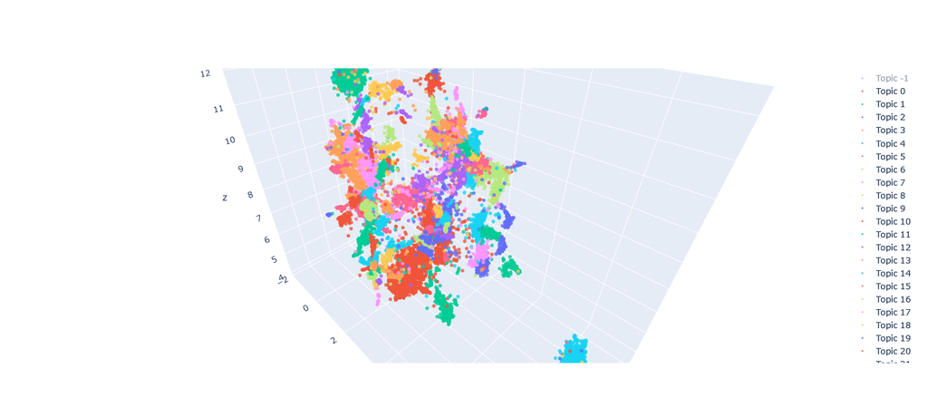

### 4.13 Topic Development

We can also inspect how a chosen number of topics develop during a certain period of time. The `visualize_topics_over_time()` function assumes that the `timestamps`, the `topic model` and the `topics over time model` are already defined (e.g., in the model preparation step after topic model training). The `timestamps` need to be `integers` or in a a certain `date format` (see model preparation step above).

```r
visualize_topics_over_time(model = topic_model,
                           # see Topic Dynamics section above
                           topics_over_time_model = topics_over_time,
                           top_n_topics = 10, # default is 20
                           filename = "topics_over_time") # default, html extension
```

[figure not shown]

### 4.14 Groups

If our dataset includes categorical variables (groups, classes, etc.), we can use the `visualize_topics_per_class()` function to display an interactive barchart with the groups or classes associated with a chosen topic. With a double-click of the mouse, the user can choose a single topic and inspect the frequency of the groups.

```r
classes = as.list(dataset$genre) # text types
topics_per_class = topic_model$topics_per_class(texts_cleaned, classes=classes)
```

```r
visualize_topics_per_class(model = topic_model,
                           topics_per_class = topics_per_class,
                           start = 0, # default class
                           end = 10, # default class
                           filename = "topics_per_class", # default, html extension
                           auto_open = FALSE) # TRUE enables output in browser
```

[figure not shown]

## 5 Conclusion

`BERTopic` is an awesome topic modeling package in Python. The `bertopicr` package tries to bring some of the functionalities into an `R` programming environment with the magnificent `reticulate` package as interface to the `Python` backend.

`BERTopic` offers a number of additional functions, which will be included in subsequent versions of `bertopicr`.